### Computational Guided Inquiry for PChem (Neshyba & Guasco, 2017)

# Inferring Model Parameters From Gas Compressibility

## Objective: Infer parameters of gas models from gas compressibility data

## Pre-class activities:

1. Read the Introduction below.
2. Copy all the equations in the introduction into your lab notebook.
3. Show that the definition of $\rho$ given in the introduction, Eq. 1, leads to $\rho=P/RT$ for an ideal gas.

## Introduction

Everybody knows that gases are compressible - they become denser when the pressure goes up. But not all gases do this in exactly the same way. That's because a gas's compressibility is influenced by intermolecular forces, which we know vary from gas to gas. That, in turn, implies something rather intriguing to a physical chemist: it means that by studying gas density, we can gain insight into how gas molecules interact! That is one reason why physical chemists have long been interested in analyzing gas density.

It is useful to talk about gas compressibility in terms of a quantity call the *mole density*. Mole density is like the ordinary mass density that you're used to, but it tells you the number of moles in a given volume. Mathematically, it's defined as

$\rho = \dfrac{n}{V}$ $\qquad\qquad\qquad\qquad\qquad\qquad\qquad\qquad\qquad\qquad (1) $

It's not hard to show that, for ideal gases, the mole density is just proportional to the pressure: $\rho_{ideal}=P/RT$. For real gases, we expect some non-linear dependence. For example, the mole density of air is shown in Fig. 1. You can see that isotherms of the mole density show an increase in density with pressure, but this increase isn't linear. To a physical chemist, that's a good thing: it means there are intermolecular forces at work here!

[figure not shown]

**Figure 1**. Thermodynamic surface of the mole density, $\rho(T,P)$ of air.

Another quantity useful for analyzing gas density if the *gas compressibility factor*, $Z$. This factor is defined as the ratio of the density of an ideal gas to the density of a real gas,

$Z \equiv \dfrac{\rho_{ideal}}{\rho} = \dfrac{V}{V_{ideal}} $ $\qquad\qquad\qquad\qquad\qquad\qquad\qquad\qquad\qquad\qquad (2) $

where we have used Eq. 1 to get the last equality. Equation 2 is useful if you know $\rho(T,P)$ and would like to know what $Z(T,P)$ looks like. An example is shown in Figure 2.

[figure not shown]

**Figure 2**. Thermodynamic surface of the compressibility factor, $Z(T,P)$, of air.

Surfaces like those shown in Figs. 1 and 2 can be quite useful from a qualitative point of view. You know that gases behave ideally in the low-pressure limit, for example, so you would expect $Z \rightarrow 1$ as $P \rightarrow 0$. As can be seen from Figure 2, it does! Now look carefully at the isotherms in Fig. 2. At low temperatures (eg., at 150 K), *Z* first dips down, then goes up, with increasing pressure. At high temperatures, *Z* does not exhibit this dip. The temperature at which a gas transitions between these two patterns is called the *Boyle temperature*, $T_{Boyle}$.

When two variables depend explicitly on a third variable, there obviously exists some implicit interdependence between the first two; this is called *parametric dependence*. For example, we can talk about isotherms of $Z$, as a *parametric function* of $\rho$, designated $Z(\rho)$, for a given temperature. An isotherm of $Z(\rho)$ is displayed in Figure 3.

[figure not shown]

**Figure 3**. Isotherm *Z($\rho$)* of air derived from thermodynamic surfaces of *$\rho$(T,P)* and *Z(T,P)* from Figs 1 and 2.

Why do we care about $Z(\rho)$? You can see from Fig. 3 that $Z$ is a rather simple function of $\rho$. In fact, it is often quite well described as a simple cubic polynomial in an equation of state referred to as the *Virial Equation*,

$Z_{Virial}(\rho) = 1 + B\rho + C\rho ^2 + D\rho ^3$ $\qquad\qquad\qquad\qquad\qquad\qquad\qquad\qquad\qquad\qquad (3) $

where the coefficients $B$, $C$, and $D$ are called the second, third, and fourth *virial coefficients*. It is assumed that these coefficients are temperature-dependent. In particular, you should note that the transition mentioned previously in reference to Fig. 2 (the Boyle temperature) appears in the Virial Equation as a transition from $B < 0$ (below the Boyle temperature) to $B > 0$ (above the Boyle temperature).

Virial coefficients offer a concise way of summarizing a lot of compressibility data. But how do they provide insight into intermolecular forces? The answer is, virial coefficients can tell us about equations of state called *model equations of state*, which contain physically meaningful constants. For example, in the van der Waals model equation of state,$^1$

$P = \dfrac{nRT}{V-nb}-\dfrac{n^2 a}{V^2} \qquad$ $\qquad\qquad\qquad\qquad\qquad\qquad\qquad\qquad\qquad\qquad (4) $

the constant $a$ is a measure of the intermolecular *attractions*, and the constant $b$ is a measure of the intermolecular *repulsions*.

So the game plan is this: infer virial coefficients $B$, $C$, and $D$ from experimental data, and use those values to infer the physical parameters of model equations. How do we do that? For the van der Waals equation, if you multiply both sides of Eq. 4 by $V/nRT$, you will see that you have isolated van der Waals's equivalent of $Z$ on one side (which we call $Z_{vdW}$),

$Z_{vdW} = \dfrac{PV}{nRT} = \dfrac{V}{V-nb} - \dfrac{na}{VRT}$ $\qquad\qquad\qquad\qquad\qquad\qquad\qquad\qquad\qquad\qquad (5) $

which with the help of Eq. 1 leads to

$Z_{vdW} = \dfrac{1}{1-b\rho}-\dfrac{a}{RT}\rho$ $\qquad\qquad\qquad\qquad\qquad\qquad\qquad\qquad\qquad\qquad (6) $

This equation does not look exactly like the Virial equation (Eq. 3), but it's close. You can make it closer by doing a Taylor expansion of $Z_{vdW}$ with respect to the mole density,

$Z_{vdW,Taylor} = 1 + \left(b-\dfrac{a}{RT}\right)\rho + b^2\rho^2$ $\qquad\qquad\qquad\qquad\qquad\qquad\qquad\qquad (7) $

If you compare each term in this equation to Eq. 3, you can see that $B$ must equal the term in parenthesis, and $C$ must equal $b^2$. This approach is called *term-for-term equivalence analysis*. From there, you can solve algebraically for $a$ and $b$ in terms of $B$ and $C$. A similar approach can be used for other model gases$^1$.

In this exercise, you'll be using Python to do exactly that. From a supplied thermodynamic surface of the density, $\rho(T,P)$, you'll construct the compressibility $Z(T,P)$. From these surfaces, you'll extract $Z(\rho)$ isotherms, and fit them using Python's built-in polynomial least squares fitting function to get virial coefficients. Then, you'll construct expressions for $Z_{vdW}$, do a Taylor expansion, and carry out a term-for-term equivalence analysis. In the end, you'll have values of model gas constants based on experiment.

## In-class activities

Import various libraries.

```python
from numpy import *
from matplotlib.pyplot import *
from mpl_toolkits.mplot3d import axes3d
%matplotlib notebook
```

You'll next want to define the necessary variables, and load the appropriate text files.

```python
# Constants
n=1
R=0.082

# Load the data
P = loadtxt('P_comp.txt')
T = loadtxt('T_comp.txt')
Pgrid,Tgrid=meshgrid(P,T)
```

It's convenient to report the temperatures and pressures we're working with. Modify the cell below to finish that reporting.

```python
# Report the temperatures we are working with
print 'T = ', T

# Also report the pressures
print 'P = ', P
```

```
T =  [ 160.  180.  200.  250.  300.  350.  400.  450.  500.]
P =  [   1.01317123    5.06585613   10.13171226   20.26342452   40.52684904
   60.79027356   81.05369807  101.31712259  151.97568389  202.63424519
  253.29280648  303.95136778  405.26849037  506.58561297]
```

Now load and graph $\rho$ of the real gas as a thermodynamic surface. Make it blue.

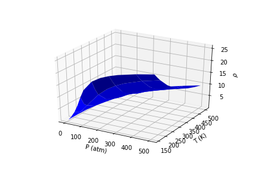

```python
# Load rho of the real gas
rho = loadtxt('rhoreal.txt')

# Open a 3-d plot window
ax = figure().gca(projection='3d') # Set up a three dimensional graphics window

# Graph rho(T,P)
ax.plot_surface(Pgrid, Tgrid, rho, rstride=2, cstride=2, color='blue') # Make the mesh plot
ax.set_xlabel('P (atm)') # Label axes
ax.set_ylabel('T (K)')
ax.set_zlabel(r'$\rho$')
```

For comparison, calculate and graph the density of an ideal gas. Make it green.

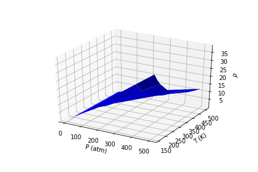

```python
# Calculate rho for an ideal gas (i.e., P/nRT, using gridded pressure and temperature)
rhoideal = Pgrid/(n*R*Tgrid)

# Open a 3-d plot window
ax = figure().gca(projection='3d') # Set up a three dimensional graphics window

# Graph rho(T,P) (ideal gas)
ax.plot_surface(Pgrid, Tgrid, rhoideal, rstride=2, cstride=2, color='blue') # Make the mesh plot
ax.set_xlabel('P (atm)') # Label axes
ax.set_ylabel('T (K)')
ax.set_zlabel(r'$\rho$')
```

#### Pause for Analysis: Make a sketch of the real and ideal thermodynamic surfaces $\rho(T,P)\space$ in your lab notebook, and make a note of the regions of state space in which the behavior of the real gas deviates most strongly from ideal behavior at low-temperature.

Next we'll get some practice with slicing some isotherms. You will be assigned a temperature for this isotherm, but how will you determine the right row of data? One way is to just try a few temperature indices until you have identified the correct value.

```python
print "T= ", T[3]
```

```
T=  250.0
```

Now make a graph of $\rho$ (real as well as ideal) as a function of pressure along your assigned isotherm. It will be convienient to make the real curve blue, and the ideal curve green. You'll probably have to change the index when you extract the isotherm, to correspond with your assigned temperature.

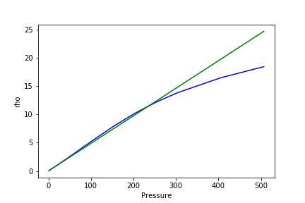

```python
# Open a figure window
figure()

# Extract real and ideal density isotherms
rhoslice = rho[3,:]
rhoidealslice = rhoideal[3,:]

# Plot the real and ideal density isotherms
plot(P,rhoslice,'blue',P,rhoidealslice,'green')
xlabel('Pressure')
ylabel('rho')
```

Now that we have calculated values of $\rho$ for both real and ideal gases, we can use them to calculate *Z* by combining Eqs. 1 and 2. After calculating *Z*, we will graph *it* as a thermodynamic surface.

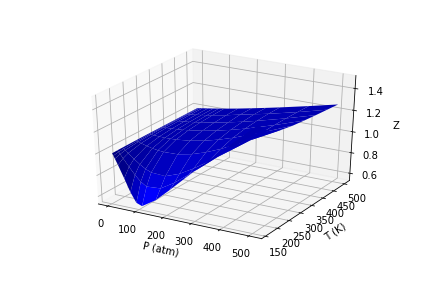

```python
# Calculate Z from density data
Z = rhoideal/rho

# Open a 3-d plot window
ax = figure().gca(projection='3d') # Set up a three dimensional graphics window

# Plot Z(T,P)
ax.plot_surface(Pgrid, Tgrid, Z, rstride=1, cstride=1, color='blue') # Make the mesh plot
ax.set_xlabel('P (atm)') # Label axes
ax.set_ylabel('T (K)')
ax.set_zlabel('Z')
```

#### Pause for Analysis: Sketch the $Z(T,P)$ surface in your notebook. In words, describe the asymptotic or limiting behaviors of $Z$, especially in the limit of low pressure. Then, from inspection of the surface, see if you can identify the temperature at which you see a transition from isotherms that dip down initially with increasing pressure, to isotherms that only exhibit positive slope with respect to pressure. This is your predicted value of the Boyle temperature of air. Record that temperature in your notebook.

For the next step you will be doing some parametric plotting. That means, you'll extract isotherms (slices) of *Z(T,P)* and $\rho (T,P)$, and graph one against the other. This will be the parametric $Z(\rho )$ isotherm. Since these are discrete experimental data points, you should plot them using markers, rather than as a line.

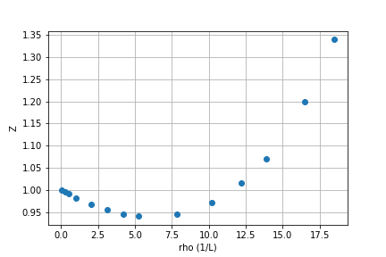

```python
# Open a figure window
figure()

# Extract an isotherm
Zslice = Z[3,:]
rhoslice = rho[3,:]

# Plot the isotherm with symbols
plot(rhoslice,Zslice,'o')
xlabel('rho (1/L)')
ylabel('Z')
grid('on')
```

#### Pause for Analysis: Does your curve exhibit the expected behavior? Here's a hint: Previously, you predicted a value for the Boyle temperature. If your assigned temperature is below that predicted value, you would expect your curve to slope downward first, then up. If your assigned temperature is above that predicted value, your curve should have positive slope everywhere.

Now that you have a plot of experimental data, you'll need to fit it with a third-order polynomial in order to get the coefficients for $Z(\rho )$ at your temperature. The code below does a second-order polynomial, so fix it to give you the $\rho^3$ coefficient.

```python
pfit = np.flipud(polyfit(rhoslice,Zslice,2))
A = pfit[0]
B = pfit[1]
C = pfit[2]
print A, B, C
```

```
1.00978218753 -0.028242506772 0.00244034322276
```

#### Pause for Analysis: Take a close look at these coefficients. First, the first value should be close to 1. Is it? Second, is the sign of $B$ consistent with your observation about the slope in your isotherm of $Z$?

Now you should be ready to construct a theoretical curve using the virial equation and the virial coefficients you just got. Construct that curve, and plot it as a line on top of the experimental values. The code below is missing the third-order part, so you should add that in.

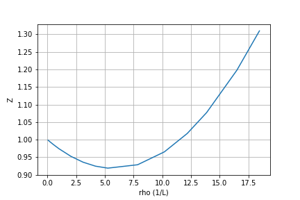

```python
# Open a figure window
figure()

# Construct a theoretical curve using the virial equation (but don't forget to add the 3rd order part)
Zfit = 1 + B*rhoslice + C*rhoslice**2

# Graph Z(rho) based on the virial equation, as a line)
plot(rhoslice,Zfit)

# Also graph Z (experimental as symbols)


# Do some labeling
xlabel('rho (1/L)')
ylabel('Z')
grid('on')
```

#### Pause for Analysis: Graphically, does your theoretical curve fit the experimental data? If not, check for mistakes in your code. When you have a good fit, record the virial coefficients that you calculated above in your notebook. Then, solve for the van der Waals parameters based on relevant equations in the Introduction.

## Post-class reflection

In your lab notebook, enter the following:

1. Your responses to the "pause for analysis" items.
2. Define the terms *compressibility factor*, *Boyle temperature*, *virial equation*, *virial coefficients*, *model equation of state*, and *term-for-term equivalence analysis*.

## References

(1) Real gas - Wikipedia, the free encyclopedia, http://en.wikipedia.org/wiki/Real_gas (*accessed September 29, 2014*).